# spaceship_titanic

**Summary**  
This notebook is primarily concerned with implementing several classification models against the spaceship titanic dataset. The dataset is an enhanced version of the classic (https://www.kaggle.com/c/titanic) for which the best approaches have been long-since developed and standardized.

Sections:  
**1) Data Manipulation & Integrity Checks**  
-Pandas  
**2) Exploratory Data Analysis**  
-Pandas, matplotlib & seaborn  
**3) Data Imputation / Feature Engineering**  
-Pandas, statistics  
**4) Execution of Multiple Classification Algorithms**  
-sklearn (logistic regression, svm, knn, ensemble models)  
**5) Model Comparison & Selection**  
-Cross-Validation  
**6) Final Submission**  
**7) Critiques and Performance**

```python
# This Python 3 environment comes with many helpful analytics libraries installed
# It is defined by the kaggle/python Docker image: https://github.com/kaggle/docker-python
# For example, here's several helpful packages to load

import numpy as np # linear algebra
import pandas as pd # data processing, CSV file I/O (e.g. pd.read_csv)
import matplotlib.pyplot as plt
import seaborn as sns

from sklearn.impute import SimpleImputer
from sklearn.pipeline import make_pipeline

from sklearn.linear_model import LogisticRegression
from sklearn.svm import SVC
from sklearn.neighbors import KNeighborsClassifier
from sklearn.ensemble import RandomForestClassifier, GradientBoostingClassifier

from sklearn.model_selection import cross_validate, GridSearchCV

# Input data files are available in the read-only "../input/" directory
# For example, running this (by clicking run or pressing Shift+Enter) will list all files under the input directory

import os
for dirname, _, filenames in os.walk('/kaggle/input'):
    for filename in filenames:
        print(os.path.join(dirname, filename))

# You can write up to 20GB to the current directory (/kaggle/working/) that gets preserved as output when you create a version using "Save & Run All"
# You can also write temporary files to /kaggle/temp/, but they won't be saved outside of the current session
```

```python
train_data = pd.read_csv("train.csv")
```

# Data Integrity Checks

The first step, after receiving the data, of just about any analytical project is to make sure that the data we have matches what we think we have. First steps for us are to check whether or not we have any missing data, any outliers and any repeated records within our dataset.

```python
train_data.columns
```

```
Index(['PassengerId', 'HomePlanet', 'CryoSleep', 'Cabin', 'Destination', 'Age',
       'VIP', 'RoomService', 'FoodCourt', 'ShoppingMall', 'Spa', 'VRDeck',
       'Name', 'Transported'],
      dtype='object')
```

```python
print("Different homeplanets individuals are from ",train_data.HomePlanet.unique())
print("Different cabins individuals are in  ",train_data.Cabin.unique())
print("Different destinations individuals are traveling to ",train_data.Destination.unique())
print("Different destinations individuals are traveling to ",train_data.VIP.unique())
```

```
Different homeplanets individuals are from  ['Europa' 'Earth' 'Mars' nan]
Different cabins individuals are in   ['B/0/P' 'F/0/S' 'A/0/S' ... 'G/1499/S' 'G/1500/S' 'E/608/S']
Different destinations individuals are traveling to  ['TRAPPIST-1e' 'PSO J318.5-22' '55 Cancri e' nan]
Different destinations individuals are traveling to  [False True nan]
```

We immediately notice that some of the categorical variables contain nan values, which is cause for concern.

```python
train_data[train_data.isna().any(axis=1)]
```

|  | PassengerId | HomePlanet | CryoSleep | Cabin | Destination | Age | VIP | RoomService | FoodCourt | ShoppingMall | Spa | VRDeck | Name | Transported |
| --- | --- | --- | --- | --- | --- | --- | --- | --- | --- | --- | --- | --- | --- | --- |
| 7 | 0006_02 | Earth | True | G/0/S | TRAPPIST-1e | 28.0 | False | 0.0 | 0.0 | 0.0 | 0.0 | NaN | Candra Jacostaffey | True |
| 10 | 0008_02 | Europa | True | B/1/P | TRAPPIST-1e | 34.0 | False | 0.0 | 0.0 | NaN | 0.0 | 0.0 | Altardr Flatic | True |
| 15 | 0012_01 | Earth | False | NaN | TRAPPIST-1e | 31.0 | False | 32.0 | 0.0 | 876.0 | 0.0 | 0.0 | Justie Pooles | False |
| 16 | 0014_01 | Mars | False | F/3/P | 55 Cancri e | 27.0 | False | 1286.0 | 122.0 | NaN | 0.0 | 0.0 | Flats Eccle | False |
| 23 | 0020_03 | Earth | True | E/0/S | 55 Cancri e | 29.0 | False | 0.0 | 0.0 | NaN | 0.0 | 0.0 | Mollen Mcfaddennon | False |
| ... | ... | ... | ... | ... | ... | ... | ... | ... | ... | ... | ... | ... | ... | ... |
| 8667 | 9250_01 | Europa | False | E/597/P | TRAPPIST-1e | 29.0 | False | 0.0 | 2972.0 | NaN | 28.0 | 188.0 | Chain Reedectied | True |
| 8674 | 9257_01 | NaN | False | F/1892/P | TRAPPIST-1e | 13.0 | False | 39.0 | 0.0 | 1085.0 | 24.0 | 0.0 | Ties Apple | False |
| 8675 | 9259_01 | Earth | NaN | F/1893/P | TRAPPIST-1e | 44.0 | False | 1030.0 | 1015.0 | 0.0 | 11.0 | NaN | Annah Gilleyons | True |
| 8684 | 9274_01 | NaN | True | G/1508/P | TRAPPIST-1e | 23.0 | False | 0.0 | 0.0 | 0.0 | 0.0 | 0.0 | Chelsa Bullisey | True |
| 8687 | 9275_03 | Europa | NaN | A/97/P | TRAPPIST-1e | 30.0 | False | 0.0 | 3208.0 | 0.0 | 2.0 | 330.0 | Atlasym Conable | True |

2087 rows × 14 columns

Assessing the impact of the data issues, we can see that ~25% of the records contain nan information.

```python
len(train_data[train_data.isna().any(axis=1)]) / len(train_data)
```

```
0.24007822385827676
```

```python
#Continious Variables w/ nan (most are related to amount spent in various parts of the ship)
print(len(train_data[train_data[['RoomService','FoodCourt','ShoppingMall','Spa','VRDeck', 'Age']].isna().any(axis=1)]) / len(train_data))
#Categorical Variables w/ nan
print(len(train_data[train_data[['HomePlanet','CryoSleep','Cabin','Destination','VIP']].isna().any(axis=1)]) / len(train_data))
#Likely irrelevant predictive variable "name"
print(len(train_data[train_data[['Name']].isna().any(axis=1)]) / len(train_data))
```

```
0.12343264695732198
0.11008857701598988
0.023007017140227768
```

We should check for repeat entries as well. We are primarily concerned with repeat passenger_ids and duplicate records

```python
train_data.PassengerId.value_counts()>1
```

```
0001_01    False
6136_01    False
6141_01    False
6139_06    False
6139_05    False
           ...
3126_01    False
3124_03    False
3124_02    False
3124_01    False
9280_02    False
Name: PassengerId, Length: 8693, dtype: bool
```

There aren't duplicate IDs, but there are some duplicate names

```python
train_data.Name.value_counts().sort_values(ascending=False)
```

```
Gollux Reedall        2
Dia Cartez            2
Elaney Webstephrey    2
Ankalik Nateansive    2
Juane Popelazquez     2
                     ..
Diram Conable         1
Atlasym Conable       1
Gravior Noxnuther     1
Kurta Mondalley       1
Propsh Hontichre      1
Name: Name, Length: 8473, dtype: int64
```

Upon further inspection, we can see that it is not an actual repeat individual, which reduces our need to manually massage the data any further

```python
train_data[train_data['Name'] == 'Gollux Reedall']
```

|  | PassengerId | HomePlanet | CryoSleep | Cabin | Destination | Age | VIP | RoomService | FoodCourt | ShoppingMall | Spa | VRDeck | Name | Transported |
| --- | --- | --- | --- | --- | --- | --- | --- | --- | --- | --- | --- | --- | --- | --- |
| 827 | 0881_01 | Europa | False | D/32/S | TRAPPIST-1e | 41.0 | False | 3103.0 | 3.0 | 0.0 | 31.0 | 26.0 | Gollux Reedall | False |
| 2852 | 3081_01 | Europa | False | C/118/S | 55 Cancri e | 50.0 | False | 0.0 | 1547.0 | 0.0 | 1784.0 | 1.0 | Gollux Reedall | True |

Cabins follows an interesting structure. It contains an alphanumeric category, followed by a number, followed by another alphanumeric category. From the prompt - we see that the logic is deck/num/side. This variable would be treated as a categorical variable if we do not engineer it a bit. In a basic logistic classification model we would treat each of these cabins as a categorical variable. As shown below, there are way too cabins for this to make logical sense. We make the decision to break apart this data into three different variables, Deck, Num and Side.

```python
print("There are ", len(train_data['Cabin'].unique()) , "unique cabins for ",\
      len(train_data['PassengerId'].unique()), " passengers")
```

```
There are  6561 unique cabins for  8693  passengers
```

```python
train_data[['Deck', 'Number','Side']] = train_data['Cabin'].apply(lambda x: pd.Series(str(x).split("/")))
```

**Conclusions of Basic Data Checks**

- We have widespread 'nan' values throughout our dataset, both on categorical variables as well as continious variables. We will likely have to decide how to account for those variables in our modeling.
- We do have repeat passenger names, but they are not likely to be a data-related issue. Rather, they are truly passengers with the same name, who are different individuals
- We do not have repeat Passenger IDs
- There are too many cabins included in our dataset. We have rationalized the field into 3 different fields: Deck, Number and Side.

# Exploratory Data Analysis

**Visualization of the Categorical variables**

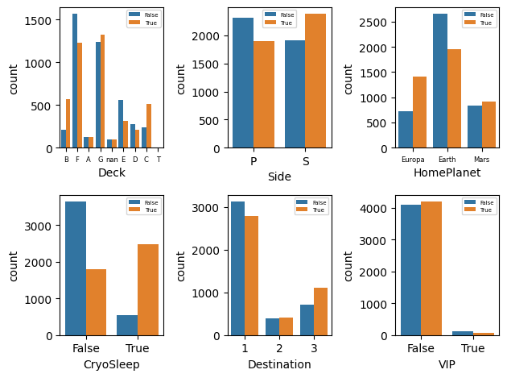

```python
fig, ax = plt.subplots(ncols=3, nrows=2)
sns.countplot(x="Deck", hue="Transported", data=train_data, ax = ax[0,0]).legend(fontsize = 5)
sns.countplot(x="Side", hue="Transported", data=train_data, ax = ax[0,1]).legend(fontsize = 5)
sns.countplot(x="HomePlanet", hue="Transported", data=train_data, ax = ax[0,2]).legend(fontsize = 5)
sns.countplot(x="CryoSleep", hue="Transported", data=train_data, ax = ax[1,0]).legend(fontsize = 5)
sns.countplot(x="Destination", hue="Transported", data=train_data, ax = ax[1,1]).legend(fontsize = 5)
sns.countplot(x="VIP", hue="Transported", data=train_data, ax = ax[1,2]).legend(fontsize = 5)
ax[0,0].xaxis.set_tick_params(labelsize=6)
ax[0,2].xaxis.set_tick_params(labelsize=6)
ax[1,1].set_xticklabels([1,2,3])
fig.tight_layout()
```

**Visualization of Continuous Variables**

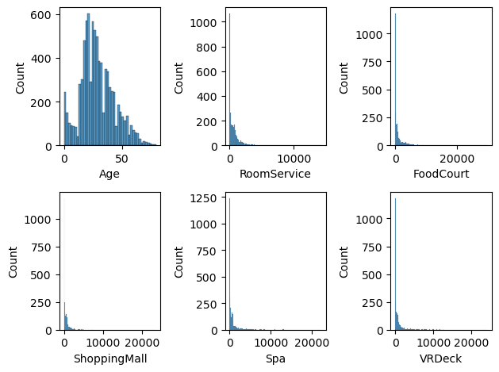

```python
fig, ax = plt.subplots(ncols=3, nrows=2)
sns.histplot(x="Age", data=train_data, ax = ax[0,0])
sns.histplot(x="RoomService", data=train_data[train_data['RoomService']>0], ax = ax[0,1])
sns.histplot(x="FoodCourt", data=train_data[train_data['FoodCourt']>0], ax = ax[0,2])
sns.histplot(x="ShoppingMall", data=train_data[train_data['ShoppingMall']>0], ax = ax[1,0])
sns.histplot(x="Spa", data=train_data[train_data['Spa']>0], ax = ax[1,1])
sns.histplot(x="VRDeck", data=train_data[train_data['VRDeck']>0], ax = ax[1,2])

fig.tight_layout()
```

It looks like we have some outliers here. A few individuals who are spending more than 20000 credits in some of the different areas of the ship. I'll note that these may be outliers, but that doesn't mean we should assume that they are not relevant for our modeling.

```python
train_data[train_data['ShoppingMall'] > 20000]
```

|  | PassengerId | HomePlanet | CryoSleep | Cabin | Destination | Age | VIP | RoomService | FoodCourt | ShoppingMall | Spa | VRDeck | Name | Transported | Deck | Number | Side |
| --- | --- | --- | --- | --- | --- | --- | --- | --- | --- | --- | --- | --- | --- | --- | --- | --- | --- |
| 8415 | 8989_01 | Europa | False | B/291/P | TRAPPIST-1e | 17.0 | False | 0.0 | 366.0 | 23492.0 | 356.0 | 3.0 | NaN | True | B | 291 | P |

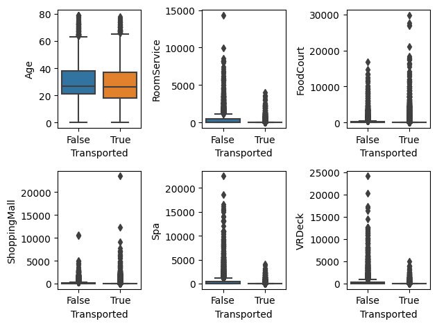

```python
fig, ax = plt.subplots(ncols=3, nrows=2)
sns.boxplot(x="Transported", y="Age", data=train_data, ax = ax[0,0])
sns.boxplot(y="RoomService", x="Transported", data=train_data, ax = ax[0,1])
sns.boxplot(y="FoodCourt", x="Transported", data=train_data, ax = ax[0,2])
sns.boxplot(y="ShoppingMall", x="Transported", data=train_data, ax = ax[1,0])
sns.boxplot(y="Spa", x="Transported", data=train_data, ax = ax[1,1])
sns.boxplot(y="VRDeck", x="Transported", data=train_data, ax = ax[1,2])

fig.tight_layout()
```

We can see the spending habits have exceptionally long tails, both based on the histograms and boxplots.

**Conclusions, EDA:**

1) Categorical variables seem to play a heavy role in an individuals likelihood to survive. Of particular note are CryoSleep, Destination and Deck.  
2) We have concerns about the outliers contained in the continious variables. They cause our distributions to have an extreme right tail, which could impact subsequent models.

# Handling nan values

**As noted, there are many records with nan values in various fields. We need to clean those up before we implement our modeling approach**  
Our options:  
A) Ignore any record with nan completely  
B) Ignore entries with nan categorical variables  
C) Ignore entries with nan continious variables  
D) Fill in continious variables with logical imputed value (0, median, regression, average, etc.)  
E) Fill in categorical variables with logical imputed value (mode, logistic regression)  
F) Some combination of B, C, D, E

First off, it is unlikely to be a wise move to drop all records with nan values. The number of records w/ NaNs are considerable (~24%) of our dataset. At that amount of records, we could unintentionally be ommitting certain sub-populations from our training which would be included in the actual test data set, causing poor performance.

```python
train_data['has_nans'] = train_data.isna().any(axis=1)
```

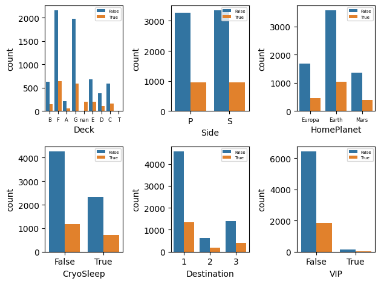

```python
fig, ax = plt.subplots(ncols=3, nrows=2)
sns.countplot(x="Deck", hue="has_nans", data=train_data, ax = ax[0,0]).legend(fontsize = 5)
sns.countplot(x="Side", hue="has_nans", data=train_data, ax = ax[0,1]).legend(fontsize = 5)
sns.countplot(x="HomePlanet", hue="has_nans", data=train_data, ax = ax[0,2]).legend(fontsize = 5)
sns.countplot(x="CryoSleep", hue="has_nans", data=train_data, ax = ax[1,0]).legend(fontsize = 5)
sns.countplot(x="Destination", hue="has_nans", data=train_data, ax = ax[1,1]).legend(fontsize = 5)
sns.countplot(x="VIP", hue="has_nans", data=train_data, ax = ax[1,2]).legend(fontsize = 5)
ax[0,0].xaxis.set_tick_params(labelsize=6)
ax[0,2].xaxis.set_tick_params(labelsize=6)
ax[1,1].set_xticklabels([1,2,3])
fig.tight_layout()
```

**Decision:** We make the decision to impute values for our nan values. I'll note that this is part of the art vs. science of model building. If the performance of the model is poor, this would be a good place to revisit to try and improve our modeling.

**Handling Continious Variables**

In this case, we decide to fill in continious variables with a 0 value - as the majority of those fields are related to spending habits of individuals. The one field of concern is that of "age", which we will have to handle differently, by imputing the average of the rest of the population.

```python
#handle 'spend' vars
spend_vars = [['RoomService','FoodCourt','ShoppingMall','Spa','VRDeck']]
zero_imputer = SimpleImputer(strategy='constant', fill_value = 0)
for x in spend_vars:
    train_data[x] = zero_imputer.fit_transform(train_data[x])
#handle age var
mean_imputer = SimpleImputer(strategy='mean')
train_data['Age'] = mean_imputer.fit_transform(train_data['Age'].values.reshape(-1, 1))
```

**Handling Categorical Variables**

We can impute the categorical variables using a simple mode method. Additional methods include knn_imputation and even building logistic regression models within our dataset, but we attempt our first pass using mode.

```python
#handle cat vars
cat_vars = [['HomePlanet', 'CryoSleep', 'Destination','VIP','Deck','Side']]
mode_imputer = SimpleImputer(strategy='most_frequent')
train_data = train_data.replace('nan', np.nan)
for x in cat_vars:
    train_data[x] = mode_imputer.fit_transform(train_data[x])
```

# Removal of irrelevant variables

At this point it is worth noting that we will not be using several variables in our modeling:  
1) PassengerID - Unique ID for each record. Identifier that is not relevant for our modeling.  
2) Cabin - Feature that was engineered into others  
3) Number - The room number, the numbering sequence method is unknown and therefore difficult to implement into our model. Additionally, categorical variables 'deck' and 'side' contain similar information.  
4) Name - similar concept to PassengerID, this is not relevant.  
5) has_nans - working column that we do not need.

# Building Models

**Finally, we can build our models**

We will evaluate 5 different models here: 1) Logistic Regression  
2) SVM  
3) KNN  
4) Random Forest  
5) GBM

We will use 10-fold cross-validation to evaluate each model and work to understand which is better than the other.

```python
X_train = pd.get_dummies(train_data[['HomePlanet', 'CryoSleep', 'Destination', 'Age',
       'VIP', 'RoomService', 'FoodCourt', 'ShoppingMall', 'Spa', 'VRDeck',
        'Deck', 'Side']])
y_train = train_data['Transported']
```

```python
#Logistic Model
logistic_model = LogisticRegression(solver='liblinear', random_state=0)
logistic_score = cross_validate(logistic_model, X_train, y_train, cv=10)
```

```python
#SVM model
svm_model = SVC()
svm_score = cross_validate(svm_model, X_train, y_train, cv=10)
```

```python
#KNN Model
KNN_model = KNeighborsClassifier()
KNN_score = cross_validate(KNN_model, X_train, y_train, cv=10)
```

```python
#Random Forest,
RF_model = RandomForestClassifier()
RF_score = cross_validate(RF_model, X_train, y_train, cv=10)
```

```python
#Finally a GBM Model
GBM_model = GradientBoostingClassifier()
GBM_score = cross_validate(GBM_model, X_train, y_train, cv=10)
```

[output not shown]

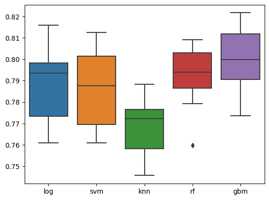

```python
#Now we can compare the performance of these models
model_performance = [logistic_score['test_score'],svm_score['test_score'], KNN_score['test_score'], RF_score['test_score'], GBM_score['test_score']]
sns.boxplot(data = model_performance).set_xticklabels(['log','svm','knn','rf','gbm'])
```

# Feature Impact & Model Tuning

If we believe that the random forest and gbm model are the better performing models, we should do some analysis to understand *how* they arrived at this performance. Although ensemble models can be considered a "black box" - there are some tools that we can use in an attempt to understand feature importances.

```python
RF_model.fit(X_train,y_train)
GBM_model.fit(X_train,y_train)
```

```
GradientBoostingClassifier()
```

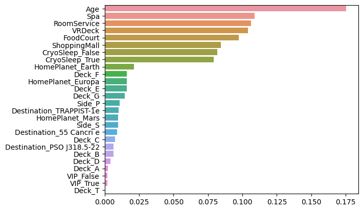

```python
forest_importances = pd.Series(RF_model.feature_importances_, index=RF_model.feature_names_in_)
forest_importances.sort_values(ascending = False, inplace=True)
sns.barplot(y = forest_importances.index, x = forest_importances.values)
```

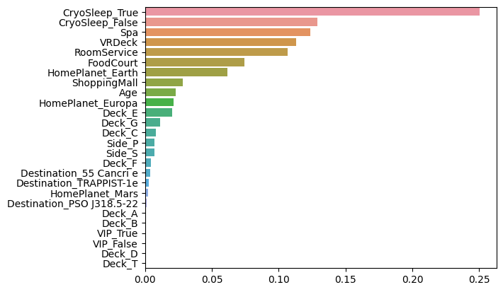

```python
GBM_importances = pd.Series(GBM_model.feature_importances_, index=GBM_model.feature_names_in_)
GBM_importances.sort_values(ascending = False, inplace=True)
sns.barplot(y = GBM_importances.index, x = GBM_importances.values)
```

There are a couple of things to note here. The GBM model weighs our variables differently. Additionally, the GBM model gets the majority of its performance from less variables than the random forest. Let's assume that the GBM model is the better of the two and use that to submit our testing results.

# Model Tuning

We can use a gridsearch in order to find the best parameters, given a list of parameters. This is "exhaustive" in the sense that we compare multiple models, but it obviously omits models that we do not test. This can quickly become exceptionally computationally complex. Here we are comparing a subsample of models, but we could try even more via this methodology.

```python
'''parameters = {
    "learning_rate": [0.01, 0.025, 0.05, 0.075, 0.1],
    "max_depth":[2,3,4,5,6,7],
    "n_estimators":[100,125,150,175,200,225]
    }

grid_search = GridSearchCV(GradientBoostingClassifier(), parameters, cv = 10)
grid_search.fit(X_train, y_train)
print(grid_search.best_params_)
print(grid_search.best_score_)'''
print("The findings are... {'learning_rate': 0.025, 'max_depth': 5, 'n_estimators': 200}")
print("These parameters are found using the commented out part of this script.")
```

```
The findings are... {'learning_rate': 0.025, 'max_depth': 5, 'n_estimators': 200}
These parameters are found using the commented out part of this script.
```

```python
final_model = GradientBoostingClassifier(learning_rate= .025, max_depth= 5, n_estimators= 200)
```

# Formalizing Data Processing

There are three steps to our transformations and data cleansing that we have performed:

1) We transform the Cabin Field into different features  
2) We impute data for both continuous variables and categorical variables  
3) We drop irrelevant features for our modeling

We can create a quick function that performs this process so that we don't have to re-code everything on a go-forward basis.

```python
def process_data(df_train = pd.DataFrame(), df_test = pd.DataFrame()):
    #establish our variables
    spend_vars = [['RoomService','FoodCourt','ShoppingMall','Spa','VRDeck']]
    cat_vars = [['HomePlanet', 'CryoSleep', 'Destination','VIP','Deck','Side']]

    #transform cabin field and adjust the 'nan' strings
    df_train[['Deck', 'Number','Side']] = df_train['Cabin'].apply(lambda x: pd.Series(str(x).split("/")))
    df_train = df_train.replace('nan', np.nan)

    df_test[['Deck', 'Number','Side']] = df_test['Cabin'].apply(lambda x: pd.Series(str(x).split("/")))
    df_test = df_test.replace('nan', np.nan)

    #handle 'spend' vars
    zero_imputer = SimpleImputer(strategy='constant', fill_value = 0)
    for x in spend_vars:
        df_train[x] = zero_imputer.fit_transform(df_train[x])
        df_test[x] = zero_imputer.fit_transform(df_test[x])

    #handle age var
    mean_imputer = SimpleImputer(strategy='mean')
    df_train['Age'] = mean_imputer.fit_transform(df_train['Age'].values.reshape(-1, 1))
    df_test['Age'] = mean_imputer.transform(df_test['Age'].values.reshape(-1, 1))

    mode_imputer = SimpleImputer(strategy='most_frequent')
    for x in cat_vars:
        df_train[x] = mode_imputer.fit_transform(df_train[x])
        df_test[x] = mode_imputer.transform(df_test[x])

    #remove unnecessary columns
    remove_list = ['PassengerId','Name','Number']
    df_test.drop(columns = remove_list, inplace = True)
    df_train.drop(columns = remove_list, inplace = True)
    return df_test, df_train
```

# Implementing the final model

```python
test_data = pd.read_csv("test.csv")
test_data_passengers = test_data[['PassengerId']]
train_data = pd.read_csv("train.csv")
```

```python
test_data,train_data = process_data(df_train = train_data, df_test = test_data)
```

```python
X_train = pd.get_dummies(train_data[['HomePlanet', 'CryoSleep', 'Destination', 'Age',
       'VIP', 'RoomService', 'FoodCourt', 'ShoppingMall', 'Spa', 'VRDeck',
        'Deck', 'Side']])
y_train = train_data['Transported']
final_model.fit(X_train, y_train)
```

```
GradientBoostingClassifier(learning_rate=0.025, max_depth=5, n_estimators=200)
```

```python
X_test = pd.get_dummies(test_data[['HomePlanet', 'CryoSleep', 'Destination', 'Age',
       'VIP', 'RoomService', 'FoodCourt', 'ShoppingMall', 'Spa', 'VRDeck',
        'Deck', 'Side']])
```

```python
predictions = final_model.predict(X_test)
```

```python
submission = list(zip(test_data_passengers['PassengerId'],predictions))
```

```python
submission_final = pd.DataFrame(submission, columns = ['PassengerId','Transported'])
submission_final.to_csv("submission.csv", index = False)
len(submission_final)
```

```
4277
```

# Commentary and Critique of Approach

There are a couple of key ommissions in our process that I would like to call out.

First, we do not leverage any kind of robust pipeline methodology in order to formalize our data transformations and preparations. In a real-world scenario we would like to formalize and document this process so that different batches of data can be more easily inputed and executed on. Scikitlearn has several features to help with this process, aptly named "Pipelines"

Additionally, we do not do any kind of feature limitation or selection during our model-building. In the real-world, it is likely that we would like to reduce the number of features necessary for our model to run. Simple is often better and more interpretable. I would use BIC or AIC to compare the models performance and work to reduce the number of features necessary for top performance.

Finally, our EDA is relatively light. We should also explore covariances and the relationships between different variables (a categorical features impact on a continuous variable, for example). Additionally, our imputation methodology is quite basic. If we really wanted to improve upon our performance, it is likely that we would have to spend more time thinking through our imputations and making sure that they followed some kind of logic given what we see from the other records. For example, our assumption that all NaNs in spend are zero might be correct, but we could use a much more complex imputation methodology, like linear regression to make an estimate of that field.

Much of this critique relates to the need for a modeler to have a better understanding of the data and model vs. just the raw performance. In real-world scenarios - models are often only as good as they are understood by others.

## Performance of my Approach

My approach yielded about an 80% accuracy rating on its submission, which was fairly good performance despite the mentioned lack of extensive data processing and imputation. This accuracy rating was within 2-4% of the top performing submissions at the time that I took to launch and submit this project, which is encouraging. I'll likely revisit this model at some point to try and get my performance up to the highest it can be by implementing the critiques mentioned above.